# Cómo crear una encuesta en Google Forms

Codificación, niveles de medición, preguntas filtro y descarga de la base de datos

Autor/a

Nicolás Outerbridge

Fecha de publicación

20 de octubre de 2026

# 1 ¿Qué vamos a hacer?

En este tutorial construimos, paso a paso, una encuesta real en Google Forms y terminamos con una base de datos lista para analizar. Al final deberías saber:

1. **Crear** un formulario y elegir el **tipo de pregunta** correcto según el **nivel de medición** de la variable.
2. **Codificar** las preguntas: armar un libro de códigos antes de recoger datos.
3. Hacer preguntas **obligatorias** y **validar** respuestas (por ejemplo, que la edad sea un número).
4. Crear **preguntas filtro**: que una respuesta decida qué preguntas ve cada persona.
5. **Publicar**, probar y **descargar la base de datos**, y pasarla a una base codificada en R.

Todas las capturas vienen de un formulario de ejemplo, la *Encuesta de hábitos de estudio*, con estas preguntas:

Tabla 1: Preguntas del formulario de ejemplo

| N.º | Pregunta | Tipo en Forms | Nivel de medición |
| --- | --- | --- | --- |
| P1 | ¿Cuántos años cumplidos tienes? | Respuesta corta + validación numérica | Razón |
| P2 | ¿En qué tipo de establecimiento terminaste la enseñanza media? | Varias opciones | Nominal |
| P3 | ¿Qué recursos usas para estudiar? (puedes marcar más de una) | Casillas | Nominal (respuesta múltiple) |
| P4 | ¿Cuál es el nivel educacional más alto que completó tu madre? | Desplegable | Ordinal |
| P5 | ¿Qué tan satisfecho/a estás con tu rendimiento académico? | Escala lineal 1–5 | Ordinal |
| P6 | ¿Trabajas actualmente de forma remunerada? | Varias opciones (**filtro**) | Nominal (dicotómica) |
| P7 | ¿Cuántas horas trabajas en una semana normal? *(solo si P6 = Sí)* | Respuesta corta + validación numérica | Razón |
| P8 | ¿Quieres agregar algún comentario? | Párrafo | Texto abierto |

# 2 Crear el formulario

## 2.1 Paso 1: abrir Google Forms

Entra a forms.google.com con tu cuenta (la institucional `@uchile.cl` funciona igual) y haz clic en **Formulario en blanco**.

[figure not shown]

Figura 1: Pantalla de inicio de Google Forms. “Formulario en blanco” crea uno nuevo.

## 2.2 Paso 2: conocer el editor

El formulario nuevo trae una primera pregunta. Hay tres controles que usarás todo el tiempo:

1. El **menú de tipo de pregunta**, que por defecto dice *Varias opciones*.
2. El interruptor **Obligatorio**.
3. La **barra inferior**. Desde la izquierda: añadir pregunta (⊕), importar preguntas, añadir título y descripción (Tт), imagen, video y **añadir sección** (el último ícono).

[figure not shown]

Figura 2: El editor recién creado.

## 2.3 Paso 3: título y descripción

Haz clic en *Formulario sin título* y escribe el nombre de la encuesta. En la descripción explica a quién va dirigida, cuánto demora y cómo se usarán los datos (consentimiento informado).

[figure not shown]

Figura 3: Título y descripción del formulario.

**TipNumera las preguntas en el texto**

Escribe el código de la pregunta al inicio del enunciado (**P1.**, **P2.**…). Ese número pasa al encabezado de la columna en la base descargada y facilita mucho la codificación posterior.

# 3 Tipos de pregunta y niveles de medición

## 3.1 Repaso: los cuatro niveles de medición

Tabla 2: Niveles de medición

| Nivel | ¿Qué permite? | Ejemplos |
| --- | --- | --- |
| **Nominal** | Clasificar en categorías sin orden | Tipo de establecimiento, comuna, sexo, trabaja sí/no |
| **Ordinal** | Clasificar **y ordenar**, pero las distancias no son iguales | Nivel educacional, grado de acuerdo (Likert), satisfacción |
| **Intervalo** | Ordenar con distancias iguales; el cero es arbitrario | Temperatura en °C, año de nacimiento, fecha |
| **Razón** | Distancias iguales **y cero absoluto** (el 0 es ausencia) | Edad en años, horas trabajadas, ingreso, n.º de hijos |

## 3.2 ¿Qué tipo de pregunta corresponde a cada nivel?

Al hacer clic en el menú de tipo de pregunta aparecen todas las opciones:

[figure not shown]

Figura 4: Menú de tipos de pregunta.

Tabla 3: Correspondencia entre tipos de pregunta y niveles de medición

| Tipo en Forms | Nivel que suele medir | Ejemplo | Ojo con… |
| --- | --- | --- | --- |
| **Respuesta corta** | Intervalo o razón (si validas que sea número) | Edad, horas, ingreso | Sin validación la gente escribe “veinte”, “20 años”, “20,5”. **Siempre** agrega validación numérica. |
| **Párrafo** | No es una variable cuantitativa | Comentarios, “¿por qué?” | Requiere codificación cualitativa posterior. |
| **Varias opciones** | Nominal; ordinal si las categorías tienen orden | Tipo de establecimiento; sí/no | Una sola respuesta. Las categorías deben ser **exhaustivas** (agrega “Otro”) y **excluyentes**. |
| **Casillas** | Nominal de **respuesta múltiple** | Recursos de estudio, redes sociales que usa | Cada opción se convierte en una variable 0/1 (ver Sección 4.3). |
| **Desplegable** | Nominal u ordinal | Región, comuna, nivel educacional | Útil con listas largas; el encuestado no ve todas las opciones de una vez. |
| **Escala lineal** | Ordinal (tipo Likert) | Satisfacción 1–5, acuerdo 1–7 | Etiqueta los extremos. A veces se analiza como intervalo, pero eso es una decisión que hay que justificar. |
| **Calificación** (estrellas) | Ordinal | Evaluación de un servicio | Igual que la escala lineal. |
| **Cuadrícula de varias opciones** | Batería de ítems ordinales | Escala de acuerdo con 5 afirmaciones | Cada **fila** es una variable. |
| **Cuadrícula de casillas** | Respuesta múltiple por fila | Días de la semana en que hace cada actividad | Difícil de analizar; úsala poco. |
| **Fecha / Hora** | Intervalo | Fecha de nacimiento | Para la edad, mejor pedirla directo en años (razón). |
| **Subir archivos** | — | — | Exige iniciar sesión en Google; evítala en encuestas. |

**ImportanteEl nivel de medición lo define la variable, no el botón**

“Varias opciones” puede medir una variable nominal (P2: tipo de establecimiento) o una ordinal (por ejemplo, “Nunca / A veces / Siempre”). Lo que importa es si las categorías **tienen un orden**. Regla práctica: **mide al nivel más alto posible**. Si preguntas la edad exacta (razón), después puedes agruparla en tramos (ordinal); al revés no se puede.

## 3.3 Ejemplos del formulario

**Nominal, una respuesta (P2).** Tipo *Varias opciones*, con “Otro” activado para que las categorías sean exhaustivas (1). Es obligatoria (2).

[figure not shown]

Figura 5: P2: pregunta nominal con varias opciones.

**Nominal de respuesta múltiple (P3).** Tipo *Casillas* (1); la persona puede marcar varias opciones (2).

[figure not shown]

Figura 6: P3: respuesta múltiple con casillas.

**Ordinal (P4).** Tipo *Desplegable* (1). Las opciones se escriben **de menor a mayor** (2), porque ese orden será el código.

[figure not shown]

Figura 7: P4: pregunta ordinal en desplegable.

**Ordinal tipo Likert (P5).** Tipo *Escala lineal* (1); se elige el rango, aquí de 1 a 5 (2), y se etiquetan los extremos (3).

[figure not shown]

Figura 8: P5: escala lineal de 1 a 5.

# 4 Codificar las preguntas

**Codificar** es asignar a cada respuesta un valor (normalmente un número) y a cada pregunta un nombre de variable. Se hace **antes** de aplicar la encuesta, en un **libro de códigos**.

## 4.1 Por qué importa en Google Forms

Google Forms **no guarda códigos numéricos**: en la base descargada aparece el **texto** de la opción (“Particular subvencionado”), no un “2”. Por eso el libro de códigos es indispensable. Es la “traducción” que usarás después para recodificar en R, Stata, SPSS o Excel. La única excepción es la escala lineal, que ya se exporta como número.

## 4.2 Libro de códigos del ejemplo

Tabla 4: Libro de códigos

| Variable | Pregunta | Nivel | Códigos |
| --- | --- | --- | --- |
| `edad` | P1 | Razón | Valor en años (15–99) |
| `dependencia` | P2 | Nominal | 1 = Municipal · 2 = Particular subvencionado · 3 = Particular pagado · 4 = SLEP · 96 = Otro (texto en `dependencia_otro`) |
| `rec_apuntes` … `rec_ia` | P3 | Nominal (dicotómicas) | 1 = marcó la opción · 0 = no la marcó |
| `educ_madre` | P4 | Ordinal | 1 = Básica incompleta o menos · 2 = Básica completa · 3 = Media completa · 4 = Técnica o universitaria completa · 5 = Postgrado |
| `satisfaccion` | P5 | Ordinal | 1 = Muy insatisfecho/a … 5 = Muy satisfecho/a |
| `trabaja` | P6 | Nominal | 1 = Sí · 0 = No |
| `horas_trabajo` | P7 | Razón | Horas semanales |
| `comentario` | P8 | Texto | Texto libre |
| *(todas)* | — | — | **-99 = No responde** · **-88 = No aplica** (no le correspondía por el filtro) |

**NotaBuenas prácticas de codificación**

- **El orden de las opciones = el orden de los códigos.** En preguntas ordinales escribe siempre de menor a mayor y **no** actives “Ordenar las opciones aleatoriamente”.
- **Códigos reservados** para “Otro” (96), “No sabe” (98), “No responde” (-99) y “No aplica” (-88). Usa siempre los mismos en toda la encuesta.
- **Distingue “no respondió” de “no le correspondía”.** En el ejemplo, quien no trabaja no ve P7. Su celda queda vacía, pero no es un dato perdido: es un *no aplica* (-88).
- **Nombres de variable cortos**, sin tildes ni espacios: `educ_madre`, no “Nivel educacional de la madre”.

## 4.3 Preguntas de respuesta múltiple

Una pregunta de *Casillas* no cabe en una sola variable. Se codifica como **una variable dicotómica por opción** (0/1):

| Persona | P3 en la base de Forms | `rec_apuntes` | `rec_libros` | `rec_videos` | `rec_grupos` | `rec_ia` |
| --- | --- | --- | --- | --- | --- | --- |
| 1 | Apuntes propios;Videos en internet | 1 | 0 | 1 | 0 | 0 |
| 2 | Libros…;Grupos de estudio;Herramientas de IA | 0 | 1 | 0 | 1 | 1 |

Forms junta todas las opciones marcadas en una sola celda, separadas por **punto y coma**.

# 5 Preguntas obligatorias y validación

## 5.1 Hacer obligatoria una pregunta

Activa el interruptor **Obligatorio** (1). La pregunta queda marcada con un asterisco rojo y el formulario no avanza si está vacía. Desde los tres puntos (⋮) se abre **Validación de respuestas** (2).

[figure not shown]

Figura 9: Interruptor “Obligatorio” y menú de validación.

## 5.2 Validar el formato de la respuesta

En P1 (edad) se eligió **Número → Entre → 15 y 99**, con un mensaje de error personalizado:

[figure not shown]

Figura 10: Validación numérica de la edad.

Así ve el encuestado el error si escribe la edad en palabras:

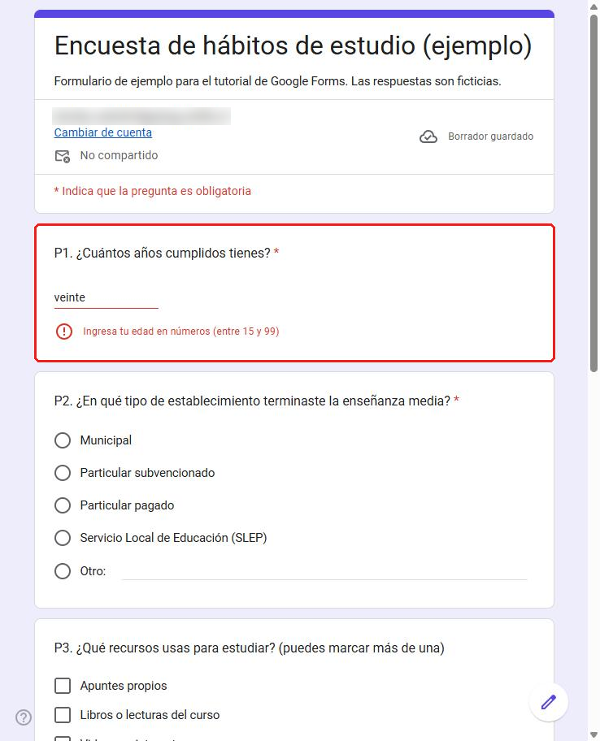

Figura 11: El formulario rechaza “veinte” y muestra el mensaje personalizado.

**Advertencia¿Todo obligatorio?**

Hacer todas las preguntas obligatorias no es mejor. Las preguntas sensibles (ingresos, salud, temas personales) conviene dejarlas opcionales o agregarles la opción “Prefiero no responder”; si no, la persona abandona la encuesta o responde cualquier cosa. Sí deben ser obligatorias **las preguntas filtro**, porque de ellas depende el recorrido.

# 6 Preguntas filtro: una respuesta decide qué preguntas siguen

Una **pregunta filtro** envía a cada persona a una parte distinta del formulario según lo que responda. En el ejemplo, solo quien **trabaja** debe responder cuántas horas trabaja:

[output not shown]

[output not shown]

En Google Forms esto se hace con **secciones**. Son tres pasos:

## 6.1 Paso 1: dividir el formulario en secciones

Pon la pregunta filtro (P6) al **final** de una sección. Luego usa el botón **Añadir sección** de la barra inferior (el último ícono) para crear la sección 2 (*Trabajo*, con P7) y la sección 3 (*Cierre*, con P8).

## 6.2 Paso 2: activar “Ir a la sección según la respuesta”

En la pregunta filtro, abre los tres puntos (⋮) y elige **Ir a la sección según la respuesta**. Solo existe en preguntas de *Varias opciones* y *Desplegable*.

[figure not shown]

Figura 12: Opción “Ir a la sección según la respuesta”.

## 6.3 Paso 3: elegir el destino de cada opción

Junto a cada respuesta aparece un menú con los destinos posibles:

[figure not shown]

Figura 13: Destinos disponibles para la opción “No”.

En el ejemplo, **Sí → Ir a la siguiente sección** (sección 2) y **No → Ir a la sección 3** (1). Revisa también el recuadro **Después de la sección…** (2), que define adónde va la gente al terminar cada sección cuando no hay filtro.

[figure not shown]

Figura 14: Filtro configurado en P6.

## 6.4 Resultado

Quien responde **Sí** llega a la sección 2 y ve la pregunta de horas:

[figure not shown]

Figura 15: P6 = Sí: el formulario muestra la sección 2.

Quien responde **No** salta directo a la sección 3:

[figure not shown]

Figura 16: P6 = No: el formulario salta a la sección 3.

**TipPrueba todos los caminos**

Antes de enviar la encuesta, respóndela tú una vez **por cada camino posible** (aquí: una vez con “Sí” y otra con “No”). Es la única forma de detectar saltos mal configurados.

# 7 Publicar y probar

En la versión actual de Google Forms el formulario no recibe respuestas hasta que lo **publicas** con el botón de avión de papel (o “Publicar”). En el cuadro de diálogo puedes **restringir** quién responde (1), por ejemplo solo cuentas de la Universidad de Chile, y luego **Publicar** (2).

[figure not shown]

Figura 17: Diálogo “Publicar formulario”.

Así ve el formulario quien responde (el asterisco indica las obligatorias):

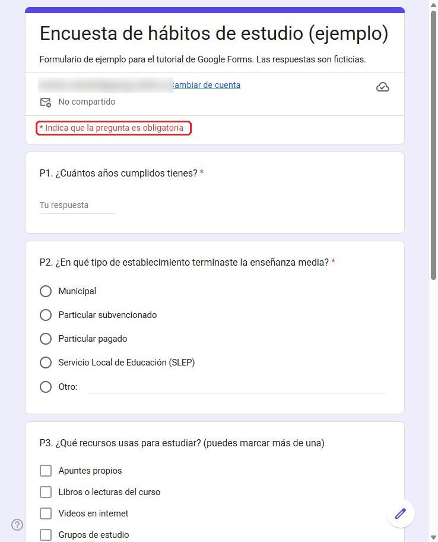

Figura 18: Vista del encuestado.

Las preguntas *Desplegable* se ven como una lista que se abre al hacer clic:

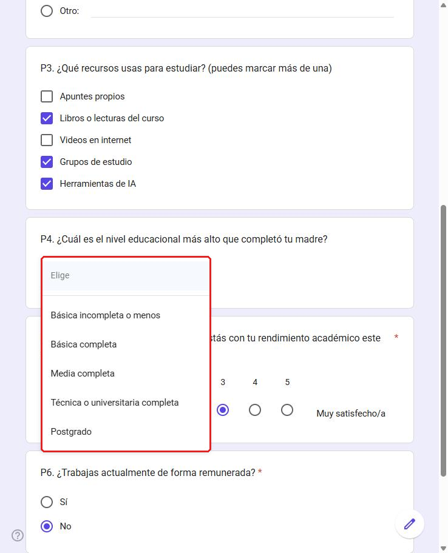

Figura 19: P4 vista por el encuestado.

**NotaRestringir o no**

Restringir a la institución obliga a iniciar sesión con una cuenta `@uchile.cl`. Sirve para encuestas internas, pero deja fuera a quien no la tenga. Para una muestra externa usa “Cualquier persona con el enlace”. En **Configuración** puedes además limitar a una respuesta por persona o recopilar correos.

# 8 Descargar la base de datos

## 8.1 La pestaña Respuestas

En **Respuestas** verás el número de respuestas y gráficos automáticos por pregunta. Para obtener la base hay dos caminos: **Vincular con Hojas de cálculo** (1) o el menú ⋮ (2).

[figure not shown]

Figura 20: Pestaña Respuestas con 4 respuestas de prueba.

## 8.2 Opción A: descargar un CSV

En el menú ⋮ elige **Descargar respuestas (.csv)**:

[figure not shown]

Figura 21: Menú con “Descargar respuestas (.csv)”.

**ImportanteLlega un .zip**

Forms descarga un archivo **.zip** que contiene el CSV. Descomprímelo antes de abrirlo en R o Excel. Si al abrirlo en Excel ves caracteres raros en las tildes, impórtalo con la codificación **UTF-8** (Datos → Desde texto/CSV).

## 8.3 Opción B: vincular con Google Sheets

**Vincular con Hojas de cálculo** crea una planilla que se **actualiza sola** con cada respuesta nueva. Es lo más cómodo mientras la encuesta está abierta. Desde Sheets puedes descargar en *Archivo → Descargar* como .xlsx o .csv.

[figure not shown]

Figura 22: Diálogo para crear o elegir la hoja de cálculo de destino.

## 8.4 Cómo viene la base

Esta es la base real descargada del formulario de ejemplo:

```r
library(readr)
cruda <- read_csv("datos/respuestas_ejemplo.csv", show_col_types = FALSE)
knitr::kable(cruda)
```

Tabla 5: Base tal como la entrega Google Forms

| Marca temporal | P1. ¿Cuántos años cumplidos tienes? | P2. ¿En qué tipo de establecimiento terminaste la enseñanza media? | P3. ¿Qué recursos usas para estudiar? (puedes marcar más de una) | P4. ¿Cuál es el nivel educacional más alto que completó tu madre? | P5. En general, ¿qué tan satisfecho/a estás con tu rendimiento académico este semestre? | P6. ¿Trabajas actualmente de forma remunerada? | P7. En una semana normal, ¿cuántas horas trabajas? | P8. ¿Quieres agregar algún comentario sobre tus hábitos de estudio? |
| --- | --- | --- | --- | --- | --- | --- | --- | --- |
| 2026/10/20 1:31:29 p. m. GMT-3 | 20 | Municipal | Apuntes propios;Videos en internet | NA | 4 | Sí | 12 | Estudio mejor de noche. |
| 2026/10/20 1:32:51 p. m. GMT-3 | 19 | Particular subvencionado | Libros o lecturas del curso;Grupos de estudio;Herramientas de IA | Técnica o universitaria completa | 3 | No | NA | NA |
| 2026/10/20 1:34:48 p. m. GMT-3 | 23 | Servicio Local de Educación (SLEP) | Apuntes propios | Básica completa | 2 | Sí | 30 | Me cuesta compatibilizar trabajo y estudio. |
| 2026/10/20 1:35:55 p. m. GMT-3 | 21 | Particular pagado | Videos en internet;Herramientas de IA | Postgrado | 5 | No | NA | NA |

Fíjate en cuatro cosas:

- **Una fila por respuesta y una columna por pregunta**, más una primera columna *Marca temporal* (fecha y hora del envío).
- Los encabezados son el **texto completo** de la pregunta. Por eso conviene numerarlas (P1, P2…).
- Las respuestas vienen como **texto**, no como códigos. Solo la escala lineal (P5) viene como número.
- **Celdas vacías** tanto para “no respondió” (P4 de la persona 1) como para “no le correspondía” (P7 de quienes no trabajan). Hay que distinguirlas con el libro de códigos.

# 9 De la base de Forms a una base codificada (R)

El siguiente código aplica el libro de códigos de la Tabla 4. Puedes copiarlo y adaptarlo a tu encuesta.

```r
library(dplyr)

# 1. Nombres de variable cortos (en el orden de las columnas)
names(cruda) <- c("fecha", "edad", "dependencia_txt", "recursos_txt",
                  "educ_madre_txt", "satisfaccion", "trabaja_txt",
                  "horas_trabajo", "comentario")

# 2. Categorías en el orden del libro de códigos
cat_dependencia <- c("Municipal", "Particular subvencionado",
                     "Particular pagado", "Servicio Local de Educación (SLEP)")
cat_educ <- c("Básica incompleta o menos", "Básica completa", "Media completa",
              "Técnica o universitaria completa", "Postgrado")

base <- cruda |>
  mutate(
    # P2 nominal: el texto se convierte en su código; lo que no calza es "Otro" (96)
    dependencia = match(dependencia_txt, cat_dependencia),
    dependencia = ifelse(is.na(dependencia) & !is.na(dependencia_txt), 96, dependencia),
    dependencia_otro = ifelse(dependencia == 96, dependencia_txt, NA),

    # P3 respuesta múltiple: una variable 0/1 por opción
    rec_apuntes = as.integer(grepl("Apuntes propios", recursos_txt, fixed = TRUE)),
    rec_libros  = as.integer(grepl("Libros o lecturas", recursos_txt, fixed = TRUE)),
    rec_videos  = as.integer(grepl("Videos en internet", recursos_txt, fixed = TRUE)),
    rec_grupos  = as.integer(grepl("Grupos de estudio", recursos_txt, fixed = TRUE)),
    rec_ia      = as.integer(grepl("Herramientas de IA", recursos_txt, fixed = TRUE)),

    # P4 ordinal: el código respeta el orden; vacío = No responde (-99)
    educ_madre = match(educ_madre_txt, cat_educ),
    educ_madre = ifelse(is.na(educ_madre), -99, educ_madre),

    # P6 dicotómica
    trabaja = ifelse(trabaja_txt == "Sí", 1, 0),

    # P7 filtrada: si no trabaja es "No aplica" (-88), no un dato perdido
    horas_trabajo = ifelse(trabaja == 0, -88, horas_trabajo)
  ) |>
  select(edad, dependencia, dependencia_otro, starts_with("rec_"),
         educ_madre, satisfaccion, trabaja, horas_trabajo, comentario)
```

```r
knitr::kable(base)
```

Tabla 6: Base codificada según el libro de códigos

| edad | dependencia | dependencia_otro | rec_apuntes | rec_libros | rec_videos | rec_grupos | rec_ia | educ_madre | satisfaccion | trabaja | horas_trabajo | comentario |
| --- | --- | --- | --- | --- | --- | --- | --- | --- | --- | --- | --- | --- |
| 20 | 1 | NA | 1 | 0 | 1 | 0 | 0 | -99 | 4 | 1 | 12 | Estudio mejor de noche. |
| 19 | 2 | NA | 0 | 1 | 0 | 1 | 1 | 4 | 3 | 0 | -88 | NA |
| 23 | 4 | NA | 1 | 0 | 0 | 0 | 0 | 2 | 2 | 1 | 30 | Me cuesta compatibilizar trabajo y estudio. |
| 21 | 3 | NA | 0 | 0 | 1 | 0 | 1 | 5 | 5 | 0 | -88 | NA |

**AdvertenciaAntes de analizar**

Los códigos -99 y -88 son **etiquetas**, no números reales. Antes de calcular promedios, conviértelos en `NA` (por ejemplo, `na_if(horas_trabajo, -88)`); si no, distorsionan los resultados. Y recuerda que el nivel de medición limita qué estadístico corresponde: moda y frecuencias para nominales; mediana y percentiles para ordinales; media y desviación estándar para intervalo y razón.

# 10 Lista de chequeo final

- Cada pregunta tiene un código (P1, P2…) en su enunciado.
- El libro de códigos está listo **antes** de publicar.
- El tipo de pregunta corresponde al nivel de medición de cada variable.
- Las preguntas numéricas tienen **validación**.
- Las categorías son exhaustivas (hay “Otro” cuando hace falta) y excluyentes.
- Las preguntas ordinales están de menor a mayor y **sin orden aleatorio**.
- Las preguntas filtro son **obligatorias** y sus saltos están probados en todos los caminos.
- Se revisó quién puede responder (restringido o con enlace) y si hay límite de una respuesta.
- Se hizo una respuesta de prueba y se descargó la base para revisarla antes de difundir la encuesta.
- Las respuestas de prueba se **eliminan** antes de abrir la encuesta (Respuestas → ⋮ → Eliminar todas las respuestas).